# Exit Survey of Australian TAFE and DETE employees

This project takes in data of exit surveys of Australian employees who worked in Australian institutions that concern employment and education. The data are taken from two different sources, namely Department of Education, Training and Employment (DETE) and the Technical and Further Education (TAFE) institute.

We would like to answer the following question:

> What are the profiles of those who resigned from these institutes?

## Filter dataset to include only relevant data

First we import the data and do some exploration

```python
import warnings
warnings.filterwarnings('ignore')

import pandas as pd
import numpy as np

#read in the data
dete_survey=pd.read_csv("dete_survey.csv")
tafe_survey=pd.read_csv("tafe_survey.csv")

#explore dete_survey
dete_survey.head()
```

|  | ID | SeparationType | Cease Date | DETE Start Date | Role Start Date | Position | Classification | Region | Business Unit | Employment Status | ... | Kept informed | Wellness programs | Health & Safety | Gender | Age | Aboriginal | Torres Strait | South Sea | Disability | NESB |
| --- | --- | --- | --- | --- | --- | --- | --- | --- | --- | --- | --- | --- | --- | --- | --- | --- | --- | --- | --- | --- | --- |
| 0 | 1 | Ill Health Retirement | 08/2012 | 1984 | 2004 | Public Servant | A01-A04 | Central Office | Corporate Strategy and Peformance | Permanent Full-time | ... | N | N | N | Male | 56-60 | NaN | NaN | NaN | NaN | Yes |
| 1 | 2 | Voluntary Early Retirement (VER) | 08/2012 | Not Stated | Not Stated | Public Servant | AO5-AO7 | Central Office | Corporate Strategy and Peformance | Permanent Full-time | ... | N | N | N | Male | 56-60 | NaN | NaN | NaN | NaN | NaN |
| 2 | 3 | Voluntary Early Retirement (VER) | 05/2012 | 2011 | 2011 | Schools Officer | NaN | Central Office | Education Queensland | Permanent Full-time | ... | N | N | N | Male | 61 or older | NaN | NaN | NaN | NaN | NaN |
| 3 | 4 | Resignation-Other reasons | 05/2012 | 2005 | 2006 | Teacher | Primary | Central Queensland | NaN | Permanent Full-time | ... | A | N | A | Female | 36-40 | NaN | NaN | NaN | NaN | NaN |
| 4 | 5 | Age Retirement | 05/2012 | 1970 | 1989 | Head of Curriculum/Head of Special Education | NaN | South East | NaN | Permanent Full-time | ... | N | A | M | Female | 61 or older | NaN | NaN | NaN | NaN | NaN |

5 rows × 56 columns

```python
#explore tafe_survey
tafe_survey.head()
```

|  | Record ID | Institute | WorkArea | CESSATION YEAR | Reason for ceasing employment | Contributing Factors. Career Move - Public Sector | Contributing Factors. Career Move - Private Sector | Contributing Factors. Career Move - Self-employment | Contributing Factors. Ill Health | Contributing Factors. Maternity/Family | ... | Workplace. Topic:Does your workplace promote a work culture free from all forms of unlawful discrimination? | Workplace. Topic:Does your workplace promote and practice the principles of employment equity? | Workplace. Topic:Does your workplace value the diversity of its employees? | Workplace. Topic:Would you recommend the Institute as an employer to others? | Gender. What is your Gender? | CurrentAge. Current Age | Employment Type. Employment Type | Classification. Classification | LengthofServiceOverall. Overall Length of Service at Institute (in years) | LengthofServiceCurrent. Length of Service at current workplace (in years) |
| --- | --- | --- | --- | --- | --- | --- | --- | --- | --- | --- | --- | --- | --- | --- | --- | --- | --- | --- | --- | --- | --- |
| 0 | 6.341330e+17 | Southern Queensland Institute of TAFE | Non-Delivery (corporate) | 2010.0 | Contract Expired | NaN | NaN | NaN | NaN | NaN | ... | Yes | Yes | Yes | Yes | Female | 26 30 | Temporary Full-time | Administration (AO) | 1-2 | 1-2 |
| 1 | 6.341337e+17 | Mount Isa Institute of TAFE | Non-Delivery (corporate) | 2010.0 | Retirement | - | - | - | - | - | ... | Yes | Yes | Yes | Yes | NaN | NaN | NaN | NaN | NaN | NaN |
| 2 | 6.341388e+17 | Mount Isa Institute of TAFE | Delivery (teaching) | 2010.0 | Retirement | - | - | - | - | - | ... | Yes | Yes | Yes | Yes | NaN | NaN | NaN | NaN | NaN | NaN |
| 3 | 6.341399e+17 | Mount Isa Institute of TAFE | Non-Delivery (corporate) | 2010.0 | Resignation | - | - | - | - | - | ... | Yes | Yes | Yes | Yes | NaN | NaN | NaN | NaN | NaN | NaN |
| 4 | 6.341466e+17 | Southern Queensland Institute of TAFE | Delivery (teaching) | 2010.0 | Resignation | - | Career Move - Private Sector | - | - | - | ... | Yes | Yes | Yes | Yes | Male | 41 45 | Permanent Full-time | Teacher (including LVT) | 3-4 | 3-4 |

5 rows × 72 columns

From looking at the above some notes:

1. The dete_survey dataframe contains 'Not Stated' values that indicate values are missing, but they aren't represented as NaN.
2. Both the dete_survey and tafe_survey contain many columns that we don't need to complete our analysis.
3. Each dataframe contains many of the same columns, but the column names are different.
4. The survey included everyone who left the company for various reasons, not exclusively resignations

To address point 1 we can read the data again but this time setting na_values="Not Stated"

```python
#Re-read the data with more consistent NaN values
dete_survey=pd.read_csv("dete_survey.csv",na_values="Not Stated")
tafe_survey=pd.read_csv("tafe_survey.csv",na_values="Not Stated")
```

To address point 2, columns 28 to 48 of dete_survey and 17 to 65 of tafe survey were decided to be irrelevant in answering the question; lets drop them

```python
#Drop unnecessary columns
dete_survey_updated=dete_survey.drop(dete_survey.columns[28:49],axis=1)
print(dete_survey_updated)
```

```
      ID                        SeparationType Cease Date  DETE Start Date  \
0      1                 Ill Health Retirement    08/2012           1984.0
1      2      Voluntary Early Retirement (VER)    08/2012              NaN
2      3      Voluntary Early Retirement (VER)    05/2012           2011.0
3      4             Resignation-Other reasons    05/2012           2005.0
4      5                        Age Retirement    05/2012           1970.0
..   ...                                   ...        ...              ...
817  819                        Age Retirement    02/2014           1977.0
818  820                        Age Retirement    01/2014           1980.0
819  821  Resignation-Move overseas/interstate    01/2014           2009.0
820  822                 Ill Health Retirement    12/2013           2001.0
821  823  Resignation-Move overseas/interstate    12/2013              NaN

     Role Start Date                                      Position  \
0             2004.0                                Public Servant
```

[output cut: 64 more lines]

```python
tafe_survey_updated=tafe_survey.drop(tafe_survey.columns[17:66],axis=1)
print(tafe_survey_updated)
```

```
        Record ID                              Institute  \
0    6.341330e+17  Southern Queensland Institute of TAFE
1    6.341337e+17            Mount Isa Institute of TAFE
2    6.341388e+17            Mount Isa Institute of TAFE
3    6.341399e+17            Mount Isa Institute of TAFE
4    6.341466e+17  Southern Queensland Institute of TAFE
..            ...                                    ...
697  6.350668e+17         Barrier Reef Institute of TAFE
698  6.350677e+17  Southern Queensland Institute of TAFE
699  6.350704e+17       Tropical North Institute of TAFE
700  6.350712e+17      Southbank Institute of Technology
701  6.350730e+17       Tropical North Institute of TAFE

                     WorkArea  CESSATION YEAR Reason for ceasing employment  \
0    Non-Delivery (corporate)          2010.0              Contract Expired
```

[output cut: 142 more lines]

To address point 3, standardize the column names on both surveys that are relevant to answering our question and convey the same information. Since the DETE columns have more comprehensible column names, we adapt TAFE's column names to follow DETE's.

```python
#First we standardize DETE's column names for easy referencing later. We standardize to snake case
dete_survey_updated.columns=dete_survey_updated.columns.str.lower()
dete_survey_updated.columns=dete_survey_updated.columns.str.strip()
dete_survey_updated.columns=dete_survey_updated.columns.str.replace(" ","_")
print(dete_survey_updated.columns)
```

```
Index(['id', 'separationtype', 'cease_date', 'dete_start_date',
       'role_start_date', 'position', 'classification', 'region',
       'business_unit', 'employment_status', 'career_move_to_public_sector',
       'career_move_to_private_sector', 'interpersonal_conflicts',
       'job_dissatisfaction', 'dissatisfaction_with_the_department',
       'physical_work_environment', 'lack_of_recognition',
       'lack_of_job_security', 'work_location', 'employment_conditions',
       'maternity/family', 'relocation', 'study/travel', 'ill_health',
       'traumatic_incident', 'work_life_balance', 'workload',
       'none_of_the_above', 'gender', 'age', 'aboriginal', 'torres_strait',
       'south_sea', 'disability', 'nesb'],
      dtype='object')
```

Now standardize column names of TAFE that convey the same information as that of DETE's

```python
#Dictionary containing column names in TAFE that are translated to corresponding columns in DETE
old_to_new_column_name={'Record ID': 'id',
'CESSATION YEAR': 'cease_date',
'Reason for ceasing employment': 'separationtype',
'Gender. What is your Gender?': 'gender',
'CurrentAge. Current Age': 'age',
'Employment Type. Employment Type': 'employment_status',
'Classification. Classification': 'position',
'LengthofServiceOverall. Overall Length of Service at Institute (in years)': 'institute_service',
'LengthofServiceCurrent. Length of Service at current workplace (in years)': 'role_service'
}

#Rename TAFE's columns
tafe_survey_updated=tafe_survey_updated.rename(old_to_new_column_name,axis=1)
print(tafe_survey_updated.columns)
```

```
Index(['id', 'Institute', 'WorkArea', 'cease_date', 'separationtype',
       'Contributing Factors. Career Move - Public Sector ',
       'Contributing Factors. Career Move - Private Sector ',
       'Contributing Factors. Career Move - Self-employment',
       'Contributing Factors. Ill Health',
       'Contributing Factors. Maternity/Family',
       'Contributing Factors. Dissatisfaction',
       'Contributing Factors. Job Dissatisfaction',
       'Contributing Factors. Interpersonal Conflict',
       'Contributing Factors. Study', 'Contributing Factors. Travel',
       'Contributing Factors. Other', 'Contributing Factors. NONE', 'gender',
       'age', 'employment_status', 'position', 'institute_service',
       'role_service'],
      dtype='object')
```

Thus now we ensure that in both dataframes the columns that convey the same information have the same name. This is important for concatenating both dataframes later

To address point 4, we first need to filter out the dataset to only include employees who leave the company by resignation. To do this, we check out the types of separation that employers have with the company (e.g. resigned, retired, etc.). This information is under the separationtype column of each dataset.

```python
#Access separationtype column statistics
tafe_survey_updated["separationtype"].value_counts()
```

```
Resignation                 340
Contract Expired            127
Retrenchment/ Redundancy    104
Retirement                   82
Transfer                     25
Termination                  23
Name: separationtype, dtype: int64
```

```python
dete_survey_updated["separationtype"].value_counts()
```

```
Age Retirement                          285
Resignation-Other reasons               150
Resignation-Other employer               91
Resignation-Move overseas/interstate     70
Voluntary Early Retirement (VER)         67
Ill Health Retirement                    61
Other                                    49
Contract Expired                         34
Termination                              15
Name: separationtype, dtype: int64
```

From the above, there are 4 types of resignations; for our objective we will only focus on these. We filter each dataset so that only rows with "resignation" are kept

```python
#Create regex pattern for filtering
pattern=r"Resignation"
#Filter both datasets to only include employees who resigned
dete_resignations=dete_survey_updated[dete_survey_updated["separationtype"].str.contains(pattern)]
tafe_resignations=tafe_survey_updated[tafe_survey_updated["separationtype"].str.contains(pattern,na=False)]
```

We would also like to standardize the length of employment of these resigned employees. The datasets contain data about the start and end year of employment. The TAFE dataset already has the employment duration under institute_service column, however the DETE doesn't. Let's create this column for DETE.

First, some of the data in cease_date and dete_start_date columns of the DETE dataset are not clean. Let's check them

```python
#Check resignation year in DETE
dete_resignations["cease_date"].value_counts()
```

```
2012       126
2013        74
01/2014     22
12/2013     17
06/2013     14
09/2013     11
07/2013      9
11/2013      9
10/2013      6
08/2013      4
05/2012      2
05/2013      2
09/2010      1
07/2012      1
2010         1
07/2006      1
Name: cease_date, dtype: int64
```

```python
#Check start year in DETE
dete_resignations["dete_start_date"].value_counts(sort=True).sort_index(ascending=False)
```

```
2013.0    10
2012.0    21
2011.0    24
2010.0    17
2009.0    13
2008.0    22
2007.0    21
2006.0    13
2005.0    15
2004.0    14
2003.0     6
2002.0     6
2001.0     3
2000.0     9
1999.0     8
1998.0     6
1997.0     5
1996.0     6
1995.0     4
1994.0     6
1993.0     5
1992.0     6
1991.0     4
1990.0     5
1989.0     4
1988.0     4
1987.0     1
1986.0     3
1985.0     3
1984.0     1
1983.0     2
1982.0     1
1980.0     5
1977.0     1
1976.0     2
1975.0     1
1974.0     2
1973.0     1
1972.0     1
1971.0     1
1963.0     1
Name: dete_start_date, dtype: int64
```

```python
#Fix cease_date column of DETE to only include year of resignation
pattern=r"([1-2][0-9]{3})"
dete_resignations["cease_date"]=dete_resignations["cease_date"].copy().str.extract(pattern).astype(float)
```

```python
#Calculate employment length of resigned employees in DETE
dete_resignations["institute_service"]=dete_resignations["cease_date"].copy()-dete_resignations["dete_start_date"].copy()
```

With this data, we can find how many years do each employee work in the DETE institute

Now that the datasets only include relevant data, we can start profiling these resigned employees.

## Classify resignations based on dissapointment

First we would like to profile resigned employees that resigned because they are dissapointed.

The datasets have columns of possible reasons of resignation, with True/False answer for each reason. In each data set, we have chosen the columns that indicate dissapointment, and the choice are as shown:

TAFE

1. Contributing Factors. Dissatisfaction
2. Contributing Factors. Job Dissatisfaction

DETE

1. job_dissatisfaction
2. dissatisfaction_with_the_department
3. physical_work_environment
4. lack_of_recognition
5. lack_of_job_security
6. work_location
7. employment_conditions
8. work_life_balance
9. workload

Let's create a new column called "dissatisfied", which will have True whenever any of the factors above are True for each resigned employee.

```python
#We do the above first for TAFE
#In the two columns indicating disappointment specified above, "-" indicates False and column name indicates True

#Initialize tafe dissatisfaction columns
tafe_dissatisfaction_columns=["Contributing Factors. Dissatisfaction","Contributing Factors. Job Dissatisfaction"]

#Check if there are null/invalid entries in the columns
for i in tafe_dissatisfaction_columns:
    print(tafe_resignations[tafe_resignations[i].isnull()])
#The print statement above shows there are 8 NaN entries in each column, and each pair reside in the same row.
#This is fortunate, since this means the invalid entries are grouped together. Thus when we create the dissatisfied column
#later, valid data in that column comes from valid data and invalid data from invalid data

#Create a function that maps - to False (i.e. not disappointed) and column name to True (i.e. disappointed)
def update_vals(value):
    if value=="-":
        return False
    elif pd.isnull(value):
        return np.nan
    return True

#Create the dissatisfied column for TAFE; if the employee answers True in any of the two columns, the dissatisfied value for
#that employee will be True. The NaN employees will remain NaN.

X=tafe_resignations[tafe_dissatisfaction_columns].applymap(update_vals).copy()
#used copy() in the above line so that if I change X (as I do below with any(), the columns in tafe_resignations remain intact)
tafe_resignations["dissatisfied"]=X.any(axis=1,skipna=False)
tafe_resignations_up=tafe_resignations.copy()
tafe_resignations_up['dissatisfied'].value_counts(dropna=False)
```

[output not shown]

```
False    241
True      91
NaN        8
Name: dissatisfied, dtype: int64
```

```python
#Now do the same operation for DETE

dete_dissatisfaction_columns=["job_dissatisfaction",
"dissatisfaction_with_the_department",
"physical_work_environment",
"lack_of_recognition",
"lack_of_job_security",
"work_location",
"employment_conditions",
"work_life_balance",
"workload"]

#Check if there are any NaN values in each column
for i in dete_dissatisfaction_columns:
    print(dete_resignations[i].isnull().sum())
#The above returned 0 for all result, and so we can be sure that all the data inside is valid.

Y=dete_resignations[dete_dissatisfaction_columns].copy()
dete_resignations["dissatisfied"]=Y.any(axis=1,skipna=False)
dete_resignations_up=dete_resignations.copy()
dete_resignations_up['dissatisfied'].value_counts(dropna=False)
```

```
False    162
True     149
Name: dissatisfied, dtype: int64
```

Now we combine our datasets.

```python
# We concatenate the rows.
# All columns will be available and NaN will be added to cells that are in one dataset but not in other

# First we create a column in each dataset to help signify which dataset the rows belong to.
dete_resignations_up["institute"]="DETE"
tafe_resignations_up["institute"]="TAFE"
# Now concatenate
combined=pd.concat([tafe_resignations_up,dete_resignations_up],axis=0)

# Next we do an extra filtering task
combined.notnull().sum().sort_values()
```

```
torres_strait                                            0
south_sea                                                3
aboriginal                                               7
disability                                               8
nesb                                                     9
business_unit                                           32
classification                                         161
region                                                 265
role_start_date                                        271
dete_start_date                                        283
role_service                                           290
career_move_to_public_sector                           311
interpersonal_conflicts                                311
job_dissatisfaction                                    311
dissatisfaction_with_the_department                    311
physical_work_environment                              311
lack_of_recognition                                    311
lack_of_job_security                                   311
career_move_to_private_sector                          311
work_location                                          311
maternity/family                                       311
relocation                                             311
study/travel                                           311
ill_health                                             311
traumatic_incident                                     311
work_life_balance                                      311
workload                                               311
none_of_the_above                                      311
employment_conditions                                  311
Contributing Factors. Ill Health                       332
Contributing Factors. Maternity/Family                 332
Contributing Factors. Career Move - Public Sector      332
Contributing Factors. Dissatisfaction                  332
Contributing Factors. Job Dissatisfaction              332
Contributing Factors. Interpersonal Conflict           332
Contributing Factors. Study                            332
Contributing Factors. Travel                           332
Contributing Factors. Other                            332
Contributing Factors. NONE                             332
Contributing Factors. Career Move - Self-employment    332
Contributing Factors. Career Move - Private Sector     332
WorkArea                                               340
Institute                                              340
institute_service                                      563
gender                                                 592
age                                                    596
employment_status                                      597
position                                               598
cease_date                                             635
dissatisfied                                           643
separationtype                                         651
institute                                              651
id                                                     651
dtype: int64
```

```python
#We saw that many columns have a lot of NaNs; we take them out and create a cleaner combined dataset.
combined_updated=combined.dropna(thresh=500,axis=1).copy()
```

After combining, we can plot how many people resigned with disappointment based on their years of service in the institutes. To more easily categorize each dissatisfied person, we can categorize them based on their career stage, defined as:

1. New: less than 3 years working in the company
2. Experienced: 3-6 years
3. Established: 7-10 years
4. Veteran: >=11 years

```python
#We check the institute_service column for this purpose, and later create a new column service_cat to categorize each person
combined_updated["institute_service"].astype("str")
combined_updated["institute_service"].value_counts(dropna=False)
```

```
NaN                   88
Less than 1 year      73
1-2                   64
3-4                   63
5-6                   33
11-20                 26
5.0                   23
1.0                   22
7-10                  21
0.0                   20
3.0                   20
6.0                   17
4.0                   16
9.0                   14
2.0                   14
7.0                   13
More than 20 years    10
8.0                    8
13.0                   8
15.0                   7
20.0                   7
10.0                   6
12.0                   6
14.0                   6
22.0                   6
17.0                   6
18.0                   5
16.0                   5
11.0                   4
23.0                   4
24.0                   4
19.0                   3
39.0                   3
21.0                   3
32.0                   3
30.0                   2
36.0                   2
28.0                   2
26.0                   2
25.0                   2
31.0                   1
29.0                   1
27.0                   1
34.0                   1
35.0                   1
38.0                   1
41.0                   1
42.0                   1
49.0                   1
33.0                   1
Name: institute_service, dtype: int64
```

```python
#Since the institute_service column is irregular, we need to extract the numbers corresponding to the period of employment

#Extract only the years inside institute_service. For those with ranges, we take the lower bound
pattern=r"(\d+)"

combined_updated["institute_service"].apply(type).nunique()

#The above indicates insitute_service contains both str and float, so we need to make all str so that we can use the
#the extract function; use astype(str) to the Series as shown below
result_pattern=combined_updated["institute_service"].astype("str").str.extract(pattern) #only extract first occurence in each
result_pattern=result_pattern.astype(float)

#Create category
def categorize(value):
    if value<3:
        return "New"
    elif 3 <= value <7:
        return "Experienced"
    elif 7<=value<11:
        return "Established"
    elif value>=11:
        return "Veteran"
    elif pd.isnull(value):
        return np.nan

#Create the new column specifying the employee's place in the category
combined_updated["service_cat"]=result_pattern.apply(categorize,axis=1,raw=True)
```

[output not shown]

Thus now we have two columns; one signifying whether the employee resigned with dissatisfaction or not, and the other categorizing how long have they worked in the company. We can finally plot, for each category (i.e. the x axis), how many of them resigned with dissapointment (in percentage) (i.e. y axis). However, each column still has NaN values, seen through the code below:

```python
combined_updated["dissatisfied"].value_counts(dropna=False)
```

[output not shown]

```python
combined_updated["service_cat"].value_counts(dropna=False)
```

```
New            193
Experienced    172
Veteran        136
NaN             88
Established     62
Name: service_cat, dtype: int64
```

We need to decide on what to do with these NaN values, since they are quite significant. For instance, service_cat has 88 NaN values, which is about 13 percent of the whole data. We decide to drop these from our analysis. For the dissatisfied column, we decide to classify NaN's as False (i.e. not disappointed). This is done below.

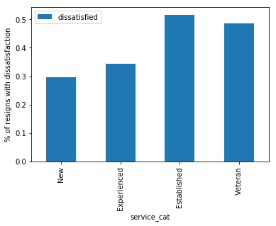

```python
# Replace missing values in combined_updated with its most frequent value (i.e. False)
combined_updated['dissatisfied'] = combined_updated['dissatisfied'].fillna(False)

# Pivot table so that index is category and values is dissatisfaction. This operation automatically drop the NaN indices.
plot_dissatisfaction=combined_updated.pivot_table(index="service_cat",values="dissatisfied")

#Finally plot the data
%matplotlib inline
import matplotlib.pyplot as plt
fig=plt.figure()
ax1=fig.add_subplot(1,1,1)
x_label_ordered=["New","Experienced","Established","Veteran"]
plot_diss=plot_dissatisfaction.reindex(x_label_ordered).plot(kind="bar",ax=ax1)
ax1.set_ylabel("% of resigns with dissatisfaction")
```

We can conclude that as an employer serves in the company longer, those who resign are likely to do so in dissatisfaction.